# EDA: Philadelphia Eviction Data Analysis

MUSA 5080 Final Project - Comprehensive Exploratory Analysis

Author

Fang Zhe

Published

December 6, 2025

# Setup

```r
library(tidyverse)
library(sf)
library(tigris)
library(viridis)
library(corrplot)
library(knitr)
library(kableExtra)
library(lubridate)
library(readxl)
library(scales)
library(patchwork)
library(spdep)  # For spatial autocorrelation

options(scipen = 999)
options(tigris_use_cache = TRUE)

# Custom plot themes
plotTheme <- theme_minimal() +
  theme(
    plot.title = element_text(size = 14, face = "bold"),
    plot.subtitle = element_text(size = 10, color = "grey40"),
    axis.title = element_text(size = 10),
    axis.text = element_text(size = 9),
    legend.position = "right",
    panel.grid.minor = element_blank()
  )

mapTheme <- theme_void() +
  theme(
    plot.title = element_text(size = 14, face = "bold"),
    plot.subtitle = element_text(size = 10, color = "grey40"),
    legend.position = "right"
  )

# Color palettes
eviction_color <- "#e31a1c"
unemp_color <- "#1f78b4"
cpi_color <- "#33a02c"
```

# Part 1: Data Loading

```r
# Load all datasets
changes_claims <- read.csv("eviction_data/changes_claims.csv")
demographics <- read.csv("eviction_data/demographics.csv")
eviction_hotspots <- read.csv("eviction_data/eviction_hotspots.csv")
filings_baseline <- read.csv("eviction_data/filings_relative_baseline.csv")
tract_filings <- read.csv("eviction_data/tract_level_filings.csv")
tract_filing_rate <- read.csv("eviction_data/tract_level_filing_rate.csv")
eviction_trends <- read.csv("eviction_data/trends_eviction.csv")

# Load Excel files
unemployment <- read_xlsx("eviction_data/unemployment_rate_montly.xlsx")
cpi <- read_xlsx("eviction_data/consumer_price_index_monthly.xlsx")
financial_health <- read_xlsx("eviction_data/financial-health-of-residents-data.xlsx")

# Data summary
cat("=== Data Loading Summary ===\n")
```

```
=== Data Loading Summary ===
```

```r
cat("Eviction trends:", nrow(eviction_trends), "months\n")
```

```
Eviction trends: 70 months
```

```r
cat("Tract-level filings:", nrow(tract_filings), "observations\n")
```

```
Tract-level filings: 408 observations
```

```r
cat("Tract filing rates:", nrow(tract_filing_rate), "observations\n")
```

```
Tract filing rates: 408 observations
```

```r
cat("Eviction hotspots:", nrow(eviction_hotspots), "locations\n")
```

```
Eviction hotspots: 75 locations
```

# Part 2: Eviction Trends Over Time

## 2.1 Monthly Eviction Filings

```r
# Parse date from eviction_trends
eviction_trends_clean <- eviction_trends %>%
  mutate(
    month_num = as.integer(substr(month, 1, 2)),
    year = as.integer(substr(month, 4, 7)),
    date = as.Date(paste0(year, "-", month_num, "-01"))
  ) %>%
  arrange(date)

cat("Eviction data:", nrow(eviction_trends_clean), "months\n")
```

```
Eviction data: 70 months
```

```r
cat("Date range:", as.character(min(eviction_trends_clean$date)), "to",
    as.character(max(eviction_trends_clean$date)), "\n")
```

```
Date range: 2020-01-01 to 2025-10-01
```

```r
# Plot monthly filings over time
ggplot(eviction_trends_clean, aes(x = date, y = month_filings)) +
  geom_line(color = eviction_color, linewidth = 1) +
  geom_point(color = eviction_color, size = 2) +
  geom_hline(yintercept = mean(eviction_trends_clean$month_filings, na.rm = TRUE),
             linetype = "dashed", color = "grey50", alpha = 0.7) +
  annotate("text", x = min(eviction_trends_clean$date),
           y = mean(eviction_trends_clean$month_filings, na.rm = TRUE) + 100,
           label = paste("Average:", round(mean(eviction_trends_clean$month_filings, na.rm = TRUE), 0)),
           hjust = 0, color = "grey50", size = 3.5) +
  labs(
    title = "Monthly Eviction Filings in Philadelphia",
    subtitle = "Tracking eviction activity over time",
    x = "Date",
    y = "Number of Filings"
  ) +
  scale_y_continuous(labels = comma) +
  scale_x_date(date_breaks = "6 months", date_labels = "%b %Y") +
  plotTheme +
  theme(axis.text.x = element_text(angle = 45, hjust = 1))
```

[output not shown]

## 2.2 Eviction Filings vs Baseline

```r
# Identify periods above/below baseline
eviction_trends_clean <- eviction_trends_clean %>%
  mutate(above_baseline = percentage_diff > 0)

ggplot(eviction_trends_clean, aes(x = date, y = percentage_diff)) +
  geom_area(aes(fill = above_baseline), alpha = 0.3) +
  geom_line(color = "grey30", linewidth = 0.8) +
  geom_point(aes(color = above_baseline), size = 2) +
  geom_hline(yintercept = 0, linetype = "dashed", color = "black", linewidth = 1) +
  scale_fill_manual(values = c("TRUE" = eviction_color, "FALSE" = unemp_color), guide = "none") +
  scale_color_manual(values = c("TRUE" = eviction_color, "FALSE" = unemp_color), guide = "none") +
  labs(
    title = "Eviction Filings Relative to Pre-Pandemic Baseline",
    subtitle = "Red = above baseline, Blue = below baseline",
    x = "Date",
    y = "Percentage Difference from Baseline (%)"
  ) +
  scale_x_date(date_breaks = "6 months", date_labels = "%b %Y") +
  plotTheme +
  theme(axis.text.x = element_text(angle = 45, hjust = 1))
```

[output not shown]

## 2.3 Year-over-Year Comparison

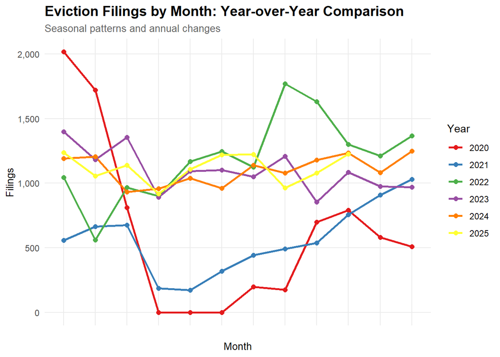

```r
# Year-over-year comparison
eviction_yoy <- eviction_trends_clean %>%
  mutate(month_name = month(date, label = TRUE)) %>%
  group_by(year, month_name) %>%
  summarize(filings = sum(month_filings, na.rm = TRUE), .groups = "drop")

ggplot(eviction_yoy, aes(x = month_name, y = filings, color = factor(year), group = year)) +
  geom_line(linewidth = 1) +
  geom_point(size = 2) +
  scale_color_brewer(palette = "Set1", name = "Year") +
  labs(
    title = "Eviction Filings by Month: Year-over-Year Comparison",
    subtitle = "Seasonal patterns and annual changes",
    x = "Month",
    y = "Filings"
  ) +
  scale_y_continuous(labels = comma) +
  plotTheme
```

# Part 3: Economic Indicators Analysis

## 3.1 Unemployment Rate Trend

```r
# Clean unemployment data - header is in row 11 (R 1-indexed)
# Use manual column names to avoid duplicate issues
unemp_clean <- unemployment[-(1:11), ]
colnames(unemp_clean) <- c("Year", "Jan", "Feb", "Mar", "Apr", "May", "Jun",
                            "Jul", "Aug", "Sep", "Oct", "Nov", "Dec")

month_names <- c("Jan","Feb","Mar","Apr","May","Jun","Jul","Aug","Sep","Oct","Nov","Dec")

unemp_long <- unemp_clean %>%
  mutate(Year = as.integer(as.numeric(Year))) %>%
  pivot_longer(cols = all_of(month_names),
               names_to = "month_name",
               values_to = "unemployment_rate") %>%
  mutate(
    unemployment_rate = as.numeric(unemployment_rate),
    month_num = match(month_name, month_names),
    date = as.Date(paste0(Year, "-", month_num, "-01"))
  ) %>%
  filter(!is.na(unemployment_rate)) %>%
  arrange(date)

cat("Unemployment data:", nrow(unemp_long), "observations\n")
```

```
Unemployment data: 116 observations
```

```r
cat("Date range:", as.character(min(unemp_long$date)), "to", as.character(max(unemp_long$date)), "\n")
```

```
Date range: 2016-01-01 to 2025-08-01
```

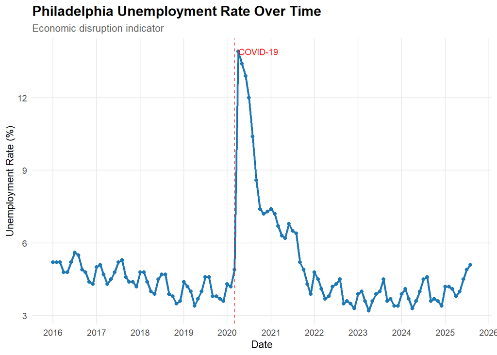

```r
ggplot(unemp_long, aes(x = date, y = unemployment_rate)) +
  geom_line(color = unemp_color, linewidth = 1) +
  geom_point(color = unemp_color, size = 1.5) +
  geom_vline(xintercept = as.Date("2020-03-01"), linetype = "dashed", color = "red", alpha = 0.7) +
  annotate("text", x = as.Date("2020-03-01"), y = max(unemp_long$unemployment_rate, na.rm = TRUE),
           label = "COVID-19", hjust = -0.1, color = "red", size = 3) +
  labs(
    title = "Philadelphia Unemployment Rate Over Time",
    subtitle = "Economic disruption indicator",
    x = "Date",
    y = "Unemployment Rate (%)"
  ) +
  scale_x_date(date_breaks = "1 year", date_labels = "%Y") +
  plotTheme
```

## 3.2 Consumer Price Index (CPI) Trend

```r
# Clean CPI data - header is in row 12 (R 1-indexed)
# CPI has 16 columns: Year + 12 months + Annual + HALF1 + HALF2
cpi_clean <- cpi[-(1:12), 1:13]  # Only keep Year + 12 months
colnames(cpi_clean) <- c("Year", "Jan", "Feb", "Mar", "Apr", "May", "Jun",
                          "Jul", "Aug", "Sep", "Oct", "Nov", "Dec")

cpi_long <- cpi_clean %>%
  mutate(Year = as.integer(as.numeric(Year))) %>%
  pivot_longer(cols = all_of(month_names),
               names_to = "month_name",
               values_to = "cpi_value") %>%
  mutate(
    cpi_value = as.numeric(cpi_value),
    month_num = match(month_name, month_names),
    date = as.Date(paste0(Year, "-", month_num, "-01"))
  ) %>%
  filter(!is.na(cpi_value)) %>%
  arrange(date)

cat("CPI data:", nrow(cpi_long), "observations\n")
```

```
CPI data: 58 observations
```

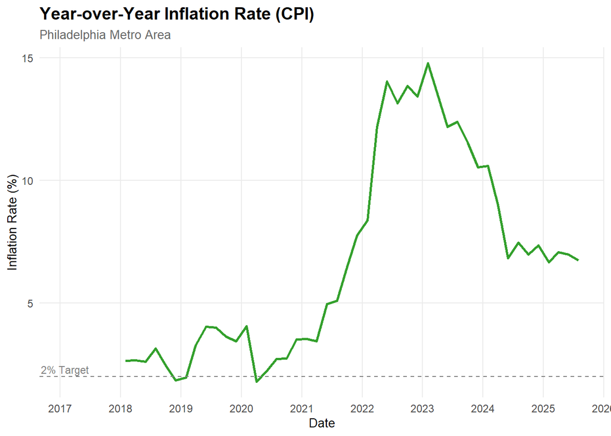

```r
# Calculate YoY inflation
cpi_long <- cpi_long %>%
  mutate(cpi_yoy_change = (cpi_value / lag(cpi_value, 12) - 1) * 100)

ggplot(cpi_long %>% filter(!is.na(cpi_yoy_change)), aes(x = date, y = cpi_yoy_change)) +
  geom_line(color = cpi_color, linewidth = 1) +
  geom_hline(yintercept = 2, linetype = "dashed", color = "grey50") +
  annotate("text", x = min(cpi_long$date, na.rm = TRUE) + 365, y = 2.3,
           label = "2% Target", color = "grey50", size = 3) +
  labs(
    title = "Year-over-Year Inflation Rate (CPI)",
    subtitle = "Philadelphia Metro Area",
    x = "Date",
    y = "Inflation Rate (%)"
  ) +
  scale_x_date(date_breaks = "1 year", date_labels = "%Y") +
  plotTheme
```

## 3.3 ⭐ Key Chart: Economic Disruption vs Evictions (Dual Y-Axis)

```r
# Merge eviction trends with economic indicators
eviction_econ <- eviction_trends_clean %>%
  left_join(unemp_long %>% select(date, unemployment_rate), by = "date") %>%
  left_join(cpi_long %>% select(date, cpi_value), by = "date")

# Check merge results
cat("Total eviction months:", nrow(eviction_trends_clean), "\n")
```

```
Total eviction months: 70
```

```r
cat("Months with unemployment data:", sum(!is.na(eviction_econ$unemployment_rate)), "\n")
```

```
Months with unemployment data: 68
```

```r
# If no overlap, create stacked plots
if(sum(!is.na(eviction_econ$unemployment_rate)) == 0) {
  cat("\n⚠️ Date ranges don't overlap! Creating separate plots...\n")

  p1 <- ggplot(eviction_trends_clean, aes(x = date, y = month_filings)) +
    geom_line(color = eviction_color, linewidth = 1) +
    geom_point(color = eviction_color, size = 2) +
    labs(title = "Eviction Filings Over Time", y = "Monthly Filings", x = "") +
    plotTheme

  p2 <- ggplot(unemp_long, aes(x = date, y = unemployment_rate)) +
    geom_line(color = unemp_color, linewidth = 1) +
    geom_point(color = unemp_color, size = 1.5) +
    labs(title = "Unemployment Rate Over Time", y = "Rate (%)", x = "Date") +
    plotTheme

  p1 / p2 + plot_annotation(title = "Economic Disruption and Evictions")

} else {
  # Filter to overlapping data
  eviction_econ_plot <- eviction_econ %>%
    filter(!is.na(unemployment_rate))

  # Calculate scaling factor
  scale_factor <- max(eviction_econ_plot$month_filings, na.rm = TRUE) /
                  max(eviction_econ_plot$unemployment_rate, na.rm = TRUE)

  # Create dual-axis plot
  ggplot(eviction_econ_plot, aes(x = date)) +
    geom_line(aes(y = month_filings, color = "Eviction Filings"), linewidth = 1.2) +
    geom_point(aes(y = month_filings, color = "Eviction Filings"), size = 2) +
    geom_line(aes(y = unemployment_rate * scale_factor, color = "Unemployment Rate"),
              linewidth = 1.2, linetype = "dashed") +
    geom_point(aes(y = unemployment_rate * scale_factor, color = "Unemployment Rate"), size = 2) +
    scale_y_continuous(
      name = "Monthly Eviction Filings",
      labels = comma,
      sec.axis = sec_axis(~./scale_factor, name = "Unemployment Rate (%)")
    ) +
    scale_color_manual(
      name = "Indicator",
      values = c("Eviction Filings" = eviction_color, "Unemployment Rate" = unemp_color)
    ) +
    labs(
      title = "Economic Disruption and Eviction Filings",
      subtitle = "Note: Negative correlation reflects COVID-19 eviction moratorium effect",
      x = "Date"
    ) +
    scale_x_date(date_breaks = "6 months", date_labels = "%b %Y") +
    plotTheme +
    theme(
      axis.text.x = element_text(angle = 45, hjust = 1),
      legend.position = "bottom",
      axis.title.y.right = element_text(color = unemp_color),
      axis.title.y.left = element_text(color = eviction_color)
    )
}
```

[output not shown]

## 3.4 Lag Effect Analysis

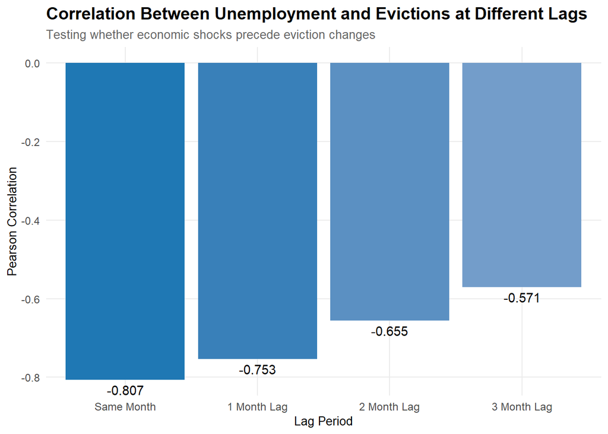

```r
# Create lagged unemployment variables
eviction_econ_lag <- eviction_econ %>%
  arrange(date) %>%
  mutate(
    unemp_lag1 = lag(unemployment_rate, 1),
    unemp_lag2 = lag(unemployment_rate, 2),
    unemp_lag3 = lag(unemployment_rate, 3),
    unemp_change = unemployment_rate - lag(unemployment_rate, 1)
  ) %>%
  filter(!is.na(unemp_lag3), !is.na(month_filings))

# Only proceed if we have enough data
if(nrow(eviction_econ_lag) >= 5) {
  # Correlation at different lags
  lag_cors <- data.frame(
    Lag = c("Same Month", "1 Month Lag", "2 Month Lag", "3 Month Lag"),
    Correlation = c(
      cor(eviction_econ_lag$month_filings, eviction_econ_lag$unemployment_rate, use = "complete.obs"),
      cor(eviction_econ_lag$month_filings, eviction_econ_lag$unemp_lag1, use = "complete.obs"),
      cor(eviction_econ_lag$month_filings, eviction_econ_lag$unemp_lag2, use = "complete.obs"),
      cor(eviction_econ_lag$month_filings, eviction_econ_lag$unemp_lag3, use = "complete.obs")
    )
  )

  # Fix the order - set factor levels explicitly
  lag_cors$Lag <- factor(lag_cors$Lag,
                         levels = c("Same Month", "1 Month Lag", "2 Month Lag", "3 Month Lag"))

  ggplot(lag_cors, aes(x = Lag, y = Correlation, fill = Correlation)) +
    geom_col() +
    geom_text(aes(label = round(Correlation, 3)), vjust = ifelse(lag_cors$Correlation > 0, -0.5, 1.5)) +
    scale_fill_gradient2(low = unemp_color, mid = "white", high = eviction_color, midpoint = 0) +
    labs(
      title = "Correlation Between Unemployment and Evictions at Different Lags",
      subtitle = "Testing whether economic shocks precede eviction changes",
      x = "Lag Period",
      y = "Pearson Correlation"
    ) +
    plotTheme +
    theme(legend.position = "none")
} else {
  cat("Not enough overlapping data for lag analysis.\n")
  cat("Available rows:", nrow(eviction_econ_lag), "\n")
}
```

# Part 4: Spatial Distribution Analysis

## 4.1 Load Census Tract Geometry

```r
# Get Philadelphia census tracts
philly_tracts <- tracts(state = "PA", county = "Philadelphia", year = 2022) %>%
  st_transform(crs = 4326)

cat("Philadelphia has", nrow(philly_tracts), "census tracts\n")
```

```
Philadelphia has 408 census tracts
```

## 4.2 Eviction Rate by Census Tract

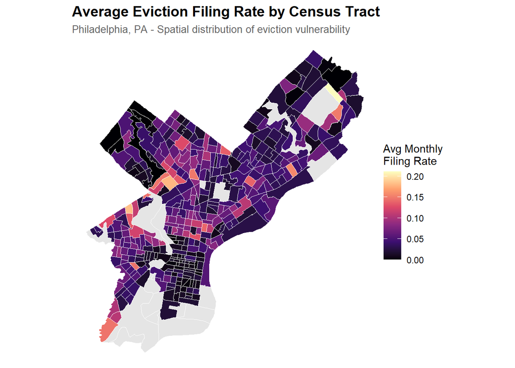

```r
# Prepare tract filings data
tract_filings_clean <- tract_filing_rate %>%
  mutate(GEOID = as.character(id)) %>%
  group_by(GEOID) %>%
  summarize(
    avg_month_rate = mean(month_rate, na.rm = TRUE),
    total_filings = sum(month_filings, na.rm = TRUE),
    n_months = n()
  )

# Join to geometry
evictions_geo <- philly_tracts %>%
  left_join(tract_filings_clean, by = "GEOID")

# Map
ggplot(evictions_geo) +
  geom_sf(aes(fill = avg_month_rate), color = "white", linewidth = 0.1) +
  scale_fill_viridis_c(option = "magma", na.value = "grey90",
                       name = "Avg Monthly\nFiling Rate") +
  labs(
    title = "Average Eviction Filing Rate by Census Tract",
    subtitle = "Philadelphia, PA - Spatial distribution of eviction vulnerability"
  ) +
  mapTheme
```

## 4.3 ⭐ Spatial Autocorrelation Analysis (Moran’s I)

```r
# Prepare data for spatial analysis
evictions_geo_clean <- evictions_geo %>%
  filter(!is.na(avg_month_rate))

cat("Tracts with eviction data:", nrow(evictions_geo_clean), "\n")
```

```
Tracts with eviction data: 389
```

```
Isolated tracts (no neighbors): 0

⚠️ Spatial analysis error: Variable contains non-finite values

Using quantile-based visualization instead...
```

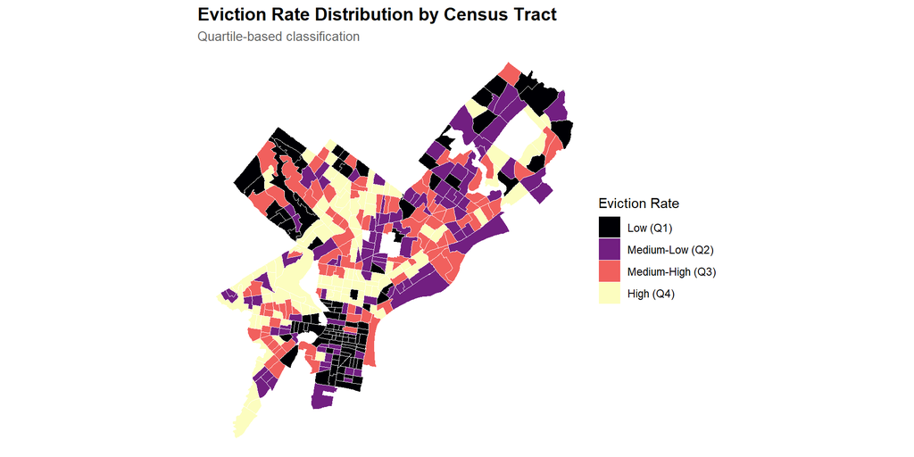

```r
# Only proceed if we have enough spatial data
if(nrow(evictions_geo_clean) >= 30) {

  # Transform to projected CRS for spatial analysis
  evictions_geo_proj <- evictions_geo_clean %>%
    st_transform(crs = 32618) %>%
    st_make_valid()  # Fix any invalid geometries

  # Try spatial autocorrelation analysis
  spatial_analysis_success <- FALSE
  moran_test <- NULL
  hotspot_tracts <- data.frame()

  tryCatch({
    # Create neighbor list
    nb <- poly2nb(evictions_geo_proj, queen = TRUE)

    # Remove isolates if any
    n_isolates <- sum(card(nb) == 0)
    cat("Isolated tracts (no neighbors):", n_isolates, "\n")

    if(n_isolates < nrow(evictions_geo_proj) / 2) {  # Only proceed if less than half are isolates

      # Create spatial weights
      lw <- nb2listw(nb, style = "W", zero.policy = TRUE)

      # Global Moran's I
      moran_result <- moran.test(evictions_geo_proj$avg_month_rate, lw,
                                  zero.policy = TRUE, na.action = na.omit)

      cat("\n=== Global Moran's I Test ===\n")
      cat("Moran's I:", round(moran_result$estimate[1], 4), "\n")
      cat("P-value:", format(moran_result$p.value, scientific = TRUE), "\n")
      cat("Interpretation:", ifelse(moran_result$p.value < 0.05,
          "SIGNIFICANT spatial clustering", "No significant clustering"), "\n")

      # Store for later use - use global assignment
      moran_test <<- moran_result

      # Local Moran's I
      local_result <- localmoran(evictions_geo_proj$avg_month_rate, lw,
                                  zero.policy = TRUE, na.action = na.omit)

      evictions_geo_proj$local_i <- local_result[, 1]
      evictions_geo_proj$local_p <- local_result[, 5]

      # Calculate spatial lag
      mean_val <- mean(evictions_geo_proj$avg_month_rate, na.rm = TRUE)
      evictions_geo_proj$lag_rate <- lag.listw(lw, evictions_geo_proj$avg_month_rate,
                                                zero.policy = TRUE, NAOK = TRUE)

      # Classify clusters - use global assignment
      evictions_geo_proj <<- evictions_geo_proj %>%
        mutate(
          lisa_cluster = case_when(
            is.na(local_p) | is.na(lag_rate) ~ "Not Significant",
            local_p > 0.05 ~ "Not Significant",
            avg_month_rate > mean_val & lag_rate > mean_val ~ "High-High (Hot Spot)",
            avg_month_rate < mean_val & lag_rate < mean_val ~ "Low-Low (Cold Spot)",
            avg_month_rate > mean_val & lag_rate < mean_val ~ "High-Low (Outlier)",
            TRUE ~ "Low-High (Outlier)"
          )
        )

      # Store hotspot tracts for summary - use global assignment
      hotspot_tracts <<- evictions_geo_proj %>%
        st_drop_geometry() %>%
        filter(lisa_cluster == "High-High (Hot Spot)")

      cat("\nLISA Cluster Summary:\n")
      print(table(evictions_geo_proj$lisa_cluster))

      # Plot LISA map
      ggplot(evictions_geo_proj %>% st_transform(4326)) +
        geom_sf(aes(fill = lisa_cluster), color = "white", linewidth = 0.1) +
        scale_fill_manual(
          values = c(
            "High-High (Hot Spot)" = "#d7191c",
            "Low-Low (Cold Spot)" = "#2c7bb6",
            "High-Low (Outlier)" = "#fdae61",
            "Low-High (Outlier)" = "#abd9e9",
            "Not Significant" = "grey90"
          ),
          name = "LISA Cluster",
          drop = FALSE
        ) +
        labs(
          title = "Local Spatial Autocorrelation (LISA) of Eviction Rates",
          subtitle = paste("Moran's I =", round(moran_result$estimate[1], 3)),
          caption = "Red = High eviction clusters | Blue = Low eviction clusters"
        ) +
        mapTheme

      spatial_analysis_success <<- TRUE
    }

  }, error = function(e) {
    cat("\n⚠️ Spatial analysis error:", conditionMessage(e), "\n")
  })

  # Fallback: Simple quantile map if spatial analysis failed
  if(!spatial_analysis_success) {
    cat("\nUsing quantile-based visualization instead...\n")

    evictions_geo_clean <- evictions_geo_clean %>%
      mutate(
        rate_category = cut(avg_month_rate,
                           breaks = quantile(avg_month_rate, probs = seq(0, 1, 0.25), na.rm = TRUE),
                           labels = c("Low (Q1)", "Medium-Low (Q2)", "Medium-High (Q3)", "High (Q4)"),
                           include.lowest = TRUE)
      )

    ggplot(evictions_geo_clean) +
      geom_sf(aes(fill = rate_category), color = "white", linewidth = 0.1) +
      scale_fill_viridis_d(option = "magma", name = "Eviction Rate") +
      labs(
        title = "Eviction Rate Distribution by Census Tract",
        subtitle = "Quartile-based classification"
      ) +
      mapTheme
  }

} else {
  cat("Not enough spatial data for analysis (need 30+ tracts, have", nrow(evictions_geo_clean), ")\n")

  # Just show basic map
  ggplot(evictions_geo) +
    geom_sf(aes(fill = avg_month_rate), color = "white", linewidth = 0.1) +
    scale_fill_viridis_c(option = "magma", na.value = "grey90") +
    labs(title = "Eviction Rates by Census Tract") +
    mapTheme
}
```

## 4.4 Eviction Hot Spots

```r
# Check if lisa_cluster exists (from section 4.3)
if(exists("evictions_geo_proj") && "lisa_cluster" %in% names(evictions_geo_proj)) {
  # Identify top hot spot tracts
  hotspot_tracts <- evictions_geo_proj %>%
    filter(lisa_cluster == "High-High (Hot Spot)") %>%
    st_drop_geometry() %>%
    arrange(desc(avg_month_rate)) %>%
    select(GEOID, avg_month_rate, total_filings, n_months)

  cat("Number of Hot Spot tracts:", nrow(hotspot_tracts), "\n")
  if(nrow(hotspot_tracts) > 0) {
    cat("Average eviction rate in hot spots:", round(mean(hotspot_tracts$avg_month_rate), 3), "\n")
    kable(head(hotspot_tracts, 10), digits = 3,
          caption = "Top 10 Eviction Hot Spot Census Tracts") %>%
      kable_styling(bootstrap_options = c("striped", "hover"))
  }
} else {
  # Fallback: show top tracts by rate (without LISA clustering)
  cat("LISA analysis not available. Showing top tracts by eviction rate:\n\n")

  hotspot_tracts <- evictions_geo %>%
    filter(!is.na(avg_month_rate)) %>%
    st_drop_geometry() %>%
    arrange(desc(avg_month_rate)) %>%
    head(10) %>%
    select(GEOID, avg_month_rate, total_filings, n_months)

  kable(hotspot_tracts, digits = 3,
        caption = "Top 10 Census Tracts by Eviction Rate") %>%
    kable_styling(bootstrap_options = c("striped", "hover"))
}
```

```
LISA analysis not available. Showing top tracts by eviction rate:
```

Top 10 Census Tracts by Eviction Rate

| GEOID | avg_month_rate | total_filings | n_months |
| --- | --- | --- | --- |
| 42101980002 | Inf | 4 | 1 |
| 42101980800 | Inf | 2 | 1 |
| 42101036100 | 0.211 | 139 | 1 |
| 42101012000 | 0.183 | 55 | 1 |
| 42101020600 | 0.180 | 107 | 1 |
| 42101032600 | 0.157 | 95 | 1 |
| 42101036201 | 0.150 | 97 | 1 |
| 42101028000 | 0.148 | 79 | 1 |
| 42101020800 | 0.148 | 117 | 1 |
| 42101005400 | 0.146 | 63 | 1 |

# Part 5: Demographic & Equity Analysis

## 5.1 Evictions by Neighborhood Racial Composition

[figure not shown]

```r
# Analyze by racial composition
tract_demo <- tract_filing_rate %>%
  mutate(
    # Note: Using pct_black (not pct_af_am) based on actual column names
    # Data uses proportions (0-1), not percentages (0-100)
    majority_type = case_when(
      pct_white > 0.5 ~ "Majority White",
      pct_black > 0.5 ~ "Majority Black",
      pct_hispanic > 0.5 ~ "Majority Hispanic",
      TRUE ~ "No Majority"
    )
  )

demo_summary <- tract_demo %>%
  group_by(majority_type) %>%
  summarize(
    avg_rate = mean(month_rate, na.rm = TRUE),
    median_rate = median(month_rate, na.rm = TRUE),
    n_obs = n(),
    n_tracts = n_distinct(id)
  ) %>%
  arrange(desc(avg_rate))

ggplot(demo_summary, aes(x = reorder(majority_type, -avg_rate), y = avg_rate, fill = majority_type)) +
  geom_col() +
  geom_errorbar(aes(ymin = avg_rate * 0.9, ymax = avg_rate * 1.1), width = 0.2) +
  geom_text(aes(label = paste0(round(avg_rate, 3), "\n(n=", n_tracts, ")")), vjust = -0.3, size = 3.5) +
  scale_fill_brewer(palette = "Set2") +
  labs(
    title = "Average Eviction Rate by Neighborhood Racial Composition",
    subtitle = "Equity Analysis: Disparities in eviction burden",
    x = "Neighborhood Type",
    y = "Average Monthly Filing Rate",
    caption = "n = number of unique census tracts"
  ) +
  plotTheme +
  theme(legend.position = "none") +
  ylim(0, max(demo_summary$avg_rate) * 1.3)
```

## 5.2 Distribution of Eviction Rates by Demographics

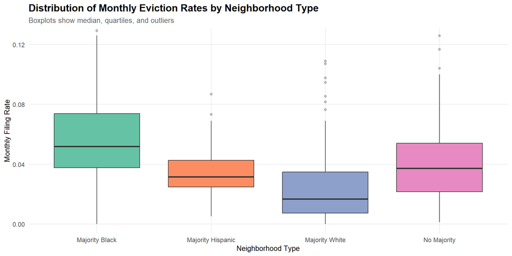

```r
# Boxplot comparison
ggplot(tract_demo, aes(x = majority_type, y = month_rate, fill = majority_type)) +
  geom_boxplot(outlier.alpha = 0.3) +
  scale_fill_brewer(palette = "Set2") +
  labs(
    title = "Distribution of Monthly Eviction Rates by Neighborhood Type",
    subtitle = "Boxplots show median, quartiles, and outliers",
    x = "Neighborhood Type",
    y = "Monthly Filing Rate"
  ) +
  plotTheme +
  theme(legend.position = "none") +
  coord_cartesian(ylim = c(0, quantile(tract_demo$month_rate, 0.95, na.rm = TRUE)))
```

## 5.3 Racial Composition vs Eviction Rate (Scatter)

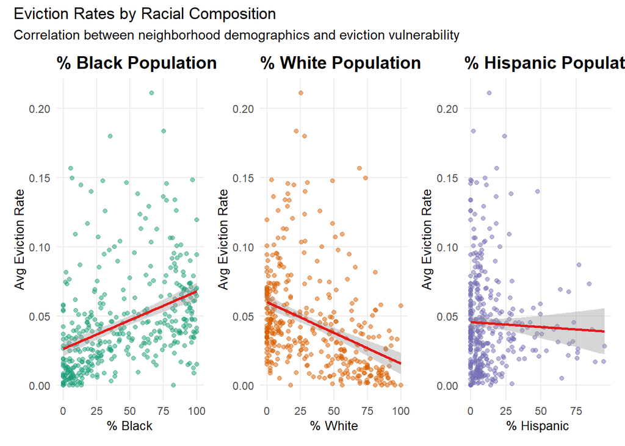

```r
# Average by tract
tract_avg <- tract_filing_rate %>%
  group_by(id) %>%
  summarize(
    avg_rate = mean(month_rate, na.rm = TRUE),
    pct_black = first(pct_black),
    pct_white = first(pct_white),
    pct_hispanic = first(pct_hispanic)
  )

p1 <- ggplot(tract_avg, aes(x = pct_black * 100, y = avg_rate)) +
  geom_point(alpha = 0.5, color = "#1b9e77") +
  geom_smooth(method = "lm", se = TRUE, color = eviction_color) +
  labs(
    title = "% Black Population",
    x = "% Black",
    y = "Avg Eviction Rate"
  ) +
  plotTheme

p2 <- ggplot(tract_avg, aes(x = pct_white * 100, y = avg_rate)) +
  geom_point(alpha = 0.5, color = "#d95f02") +
  geom_smooth(method = "lm", se = TRUE, color = eviction_color) +
  labs(
    title = "% White Population",
    x = "% White",
    y = "Avg Eviction Rate"
  ) +
  plotTheme

p3 <- ggplot(tract_avg, aes(x = pct_hispanic * 100, y = avg_rate)) +
  geom_point(alpha = 0.5, color = "#7570b3") +
  geom_smooth(method = "lm", se = TRUE, color = eviction_color) +
  labs(
    title = "% Hispanic Population",
    x = "% Hispanic",
    y = "Avg Eviction Rate"
  ) +
  plotTheme

p1 + p2 + p3 +
  plot_annotation(
    title = "Eviction Rates by Racial Composition",
    subtitle = "Correlation between neighborhood demographics and eviction vulnerability"
  )
```

## 5.4 Equity Summary Table

```r
# Detailed equity summary
equity_summary <- tract_demo %>%
  group_by(majority_type) %>%
  summarize(
    `Mean Eviction Rate` = mean(month_rate, na.rm = TRUE),
    `Median Eviction Rate` = median(month_rate, na.rm = TRUE),
    `Std Dev` = sd(month_rate, na.rm = TRUE),
    `Max Rate` = max(month_rate, na.rm = TRUE),
    `N Observations` = n(),
    `N Tracts` = n_distinct(id)
  ) %>%
  arrange(desc(`Mean Eviction Rate`))

# Calculate disparity ratio
baseline_rate <- equity_summary %>%
  filter(majority_type == "Majority White") %>%
  pull(`Mean Eviction Rate`)

equity_summary <- equity_summary %>%
  mutate(`Disparity Ratio` = `Mean Eviction Rate` / baseline_rate)

kable(equity_summary, digits = 3,
      caption = "Eviction Rate Disparities by Neighborhood Type") %>%
  kable_styling(bootstrap_options = c("striped", "hover")) %>%
  row_spec(which.max(equity_summary$`Mean Eviction Rate`), bold = TRUE, background = "#ffcccc")
```

Eviction Rate Disparities by Neighborhood Type

| majority_type | Mean Eviction Rate | Median Eviction Rate | Std Dev | Max Rate | N Observations | N Tracts | Disparity Ratio |
| --- | --- | --- | --- | --- | --- | --- | --- |
| No Majority | Inf | 0.039 | NaN | Inf | 92 | 92 | Inf |
| Majority Black | 0.060 | 0.052 | 0.034 | 0.211 | 162 | 162 | 2.324 |
| Majority Hispanic | 0.038 | 0.032 | 0.021 | 0.087 | 21 | 21 | 1.475 |
| Majority White | 0.026 | 0.017 | 0.028 | 0.157 | 133 | 133 | 1.000 |

# Part 6: Time-Space Interaction Analysis

## 6.1 Temporal Changes in Spatial Patterns

```r
# Analyze how spatial patterns change over time
tract_time <- tract_filing_rate %>%
  mutate(
    GEOID = as.character(id),
    date = as.Date(month_date)
  )

# Create time periods
tract_time <- tract_time %>%
  mutate(
    period = case_when(
      date < as.Date("2020-03-01") ~ "Pre-COVID",
      date >= as.Date("2020-03-01") & date < as.Date("2021-01-01") ~ "COVID-2020",
      date >= as.Date("2021-01-01") & date < as.Date("2022-01-01") ~ "COVID-2021",
      date >= as.Date("2022-01-01") ~ "Post-COVID"
    )
  )

# Aggregate by period and tract
period_rates <- tract_time %>%
  group_by(GEOID, period) %>%
  summarize(
    avg_rate = mean(month_rate, na.rm = TRUE),
    .groups = "drop"
  ) %>%
  pivot_wider(names_from = period, values_from = avg_rate)

# Join to geometry for mapping
period_geo <- philly_tracts %>%
  left_join(period_rates, by = "GEOID")

# Check available periods
available_periods <- names(period_rates)[-1]
cat("Available time periods:", paste(available_periods, collapse = ", "), "\n")
```

```
Available time periods: Pre-COVID
```

## 6.2 Eviction Rate Changes by Period

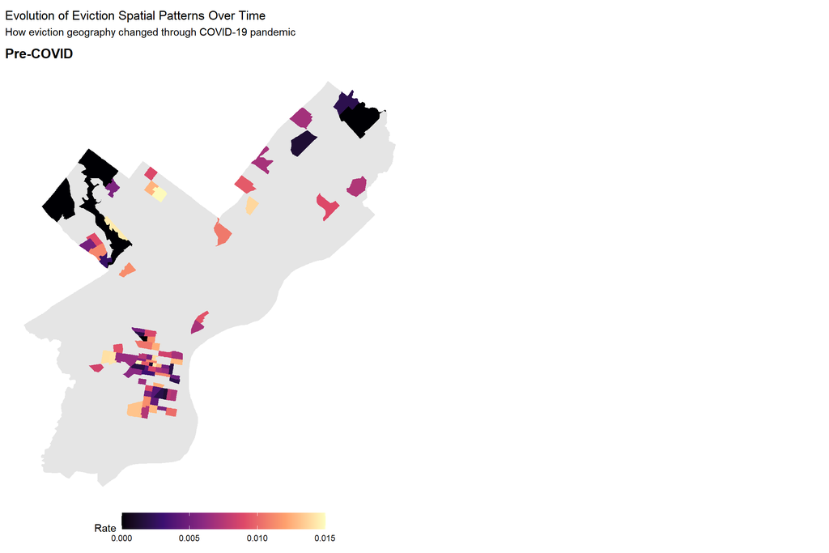

```r
# Create maps for each available period
map_list <- list()

for(period_name in available_periods) {
  if(period_name %in% names(period_geo)) {
    p <- ggplot(period_geo) +
      geom_sf(aes(fill = .data[[period_name]]), color = NA) +
      scale_fill_viridis_c(option = "magma", na.value = "grey90", limits = c(0, 0.015)) +
      labs(title = period_name, fill = "Rate") +
      mapTheme +
      theme(legend.position = "bottom", legend.key.width = unit(1.5, "cm"))
    map_list[[period_name]] <- p
  }
}

if(length(map_list) > 0) {
  wrap_plots(map_list, ncol = 2) +
    plot_annotation(
      title = "Evolution of Eviction Spatial Patterns Over Time",
      subtitle = "How eviction geography changed through COVID-19 pandemic"
    )
}
```

# Part 7: Correlation Analysis

## 7.1 Comprehensive Correlation Matrix

```
Analysis dataset has 66 observations
```

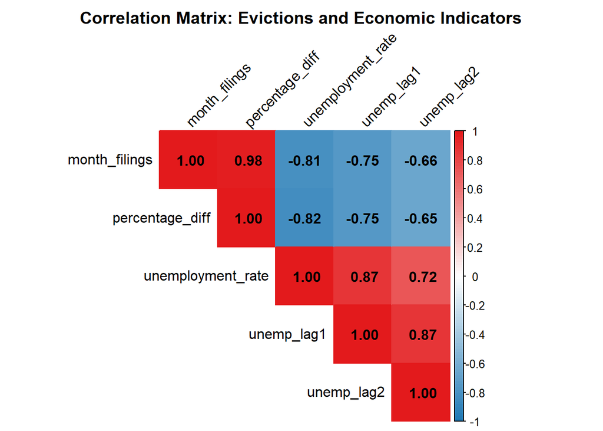

```r
# Create analysis dataset - with error handling
if(exists("eviction_econ") && nrow(eviction_econ) > 0) {
  analysis_df <- eviction_econ %>%
    filter(!is.na(unemployment_rate)) %>%
    select(date, month_filings, percentage_diff, unemployment_rate,
           any_of("cpi_value"))

  # Add lagged variables
  analysis_df <- analysis_df %>%
    arrange(date) %>%
    mutate(
      filings_change = month_filings - lag(month_filings),
      unemp_change = unemployment_rate - lag(unemployment_rate),
      unemp_lag1 = lag(unemployment_rate, 1),
      unemp_lag2 = lag(unemployment_rate, 2)
    ) %>%
    filter(!is.na(unemp_lag2))

  cat("Analysis dataset has", nrow(analysis_df), "observations\n")

  # Correlation matrix
  if(nrow(analysis_df) > 5) {
    cor_vars <- analysis_df %>%
      select(month_filings, percentage_diff, unemployment_rate, unemp_lag1, unemp_lag2) %>%
      na.omit()

    if (nrow(cor_vars) > 5) {
      cor_matrix <- cor(cor_vars)

      corrplot(cor_matrix,
               method = "color",
               type = "upper",
               addCoef.col = "black",
               tl.col = "black",
               tl.srt = 45,
               col = colorRampPalette(c(unemp_color, "white", eviction_color))(100),
               title = "Correlation Matrix: Evictions and Economic Indicators",
               mar = c(0, 0, 2, 0))
    }
  } else {
    cat("Not enough data for correlation matrix.\n")
  }
} else {
  cat("eviction_econ not available. Skipping correlation analysis.\n")
  analysis_df <- data.frame()  # Create empty df to prevent later errors
}
```

## 7.2 Key Scatter Plots

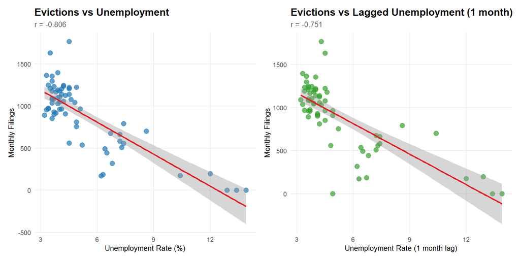

```r
if(exists("analysis_df") && nrow(analysis_df) > 5) {
  # Eviction vs Unemployment
  p1 <- ggplot(analysis_df, aes(x = unemployment_rate, y = month_filings)) +
    geom_point(color = unemp_color, alpha = 0.7, size = 3) +
    geom_smooth(method = "lm", se = TRUE, color = eviction_color) +
    labs(
      title = "Evictions vs Unemployment",
      subtitle = paste("r =", round(cor(analysis_df$month_filings, analysis_df$unemployment_rate, use = "complete.obs"), 3)),
      x = "Unemployment Rate (%)",
      y = "Monthly Filings"
    ) +
    plotTheme

  # Eviction vs Lagged Unemployment
  p2 <- ggplot(analysis_df, aes(x = unemp_lag1, y = month_filings)) +
    geom_point(color = cpi_color, alpha = 0.7, size = 3) +
    geom_smooth(method = "lm", se = TRUE, color = eviction_color) +
    labs(
      title = "Evictions vs Lagged Unemployment (1 month)",
      subtitle = paste("r =", round(cor(analysis_df$month_filings, analysis_df$unemp_lag1, use = "complete.obs"), 3)),
      x = "Unemployment Rate (1 month lag)",
      y = "Monthly Filings"
    ) +
    plotTheme

  print(p1 + p2)
} else {
  cat("Not enough overlapping data for scatter plots.\n")
}
```

# Part 8: Summary Statistics

## 8.1 Eviction Trends Summary

```r
eviction_summary <- eviction_trends_clean %>%
  summarize(
    `Mean Monthly Filings` = mean(month_filings, na.rm = TRUE),
    `SD Monthly Filings` = sd(month_filings, na.rm = TRUE),
    `Min Filings` = min(month_filings, na.rm = TRUE),
    `Max Filings` = max(month_filings, na.rm = TRUE),
    `Mean % Diff from Baseline` = mean(percentage_diff, na.rm = TRUE),
    `Months Above Baseline` = sum(percentage_diff > 0, na.rm = TRUE),
    `Total Months` = n()
  ) %>%
  pivot_longer(everything(), names_to = "Statistic", values_to = "Value")

kable(eviction_summary, digits = 2, caption = "Eviction Trends Summary") %>%
  kable_styling(bootstrap_options = c("striped", "hover"))
```

Eviction Trends Summary

| Statistic | Value |
| --- | --- |
| Mean Monthly Filings | 944.69 |
| SD Monthly Filings | 413.77 |
| Min Filings | 0.00 |
| Max Filings | 2015.00 |
| Mean % Diff from Baseline | 0.85 |
| Months Above Baseline | 67.00 |
| Total Months | 70.00 |

## 8.2 Economic Indicators Summary

```r
if(exists("analysis_df") && nrow(analysis_df) > 0) {
  econ_summary <- analysis_df %>%
    summarize(
      `Mean Unemployment Rate` = mean(unemployment_rate, na.rm = TRUE),
      `Max Unemployment Rate` = max(unemployment_rate, na.rm = TRUE),
      `Min Unemployment Rate` = min(unemployment_rate, na.rm = TRUE),
      `Correlation: Eviction-Unemployment` = cor(month_filings, unemployment_rate, use = "complete.obs"),
      `Correlation: Eviction-Lagged Unemp` = cor(month_filings, unemp_lag1, use = "complete.obs")
    ) %>%
    pivot_longer(everything(), names_to = "Statistic", values_to = "Value")

  kable(econ_summary, digits = 3, caption = "Economic Indicators Summary") %>%
    kable_styling(bootstrap_options = c("striped", "hover"))
} else {
  # Use unemp_long directly
  unemp_summary <- unemp_long %>%
    summarize(
      `Mean Unemployment Rate` = mean(unemployment_rate, na.rm = TRUE),
      `Max Unemployment Rate` = max(unemployment_rate, na.rm = TRUE),
      `Min Unemployment Rate` = min(unemployment_rate, na.rm = TRUE),
      `Observations` = n()
    ) %>%
    pivot_longer(everything(), names_to = "Statistic", values_to = "Value")

  kable(unemp_summary, digits = 3, caption = "Unemployment Data Summary") %>%
    kable_styling(bootstrap_options = c("striped", "hover"))
}
```

Economic Indicators Summary

| Statistic | Value |
| --- | --- |
| Mean Unemployment Rate | 5.200 |
| Max Unemployment Rate | 13.900 |
| Min Unemployment Rate | 3.200 |
| Correlation: Eviction-Unemployment | -0.806 |
| Correlation: Eviction-Lagged Unemp | -0.751 |

# Part 9: Key Findings & Recommendations

## 9.1 Summary of EDA Findings

Based on the comprehensive exploratory analysis, here are the key findings:

### Temporal Patterns

```r
# Calculate key temporal stats
avg_filings <- mean(eviction_trends_clean$month_filings, na.rm = TRUE)
max_filings <- max(eviction_trends_clean$month_filings, na.rm = TRUE)
max_date <- eviction_trends_clean$date[which.max(eviction_trends_clean$month_filings)]
```

1. **Average monthly eviction filings:** 945 cases
2. **Peak filings:** 2,015 cases in 一月 2020
3. **Clear seasonal patterns** with higher filings in certain months

### Economic Relationships

```r
# Calculate correlations - with fallback
if(exists("analysis_df") && nrow(analysis_df) > 5) {
  cor_unemp <- cor(analysis_df$month_filings, analysis_df$unemployment_rate, use = "complete.obs")
  cor_lag <- cor(analysis_df$month_filings, analysis_df$unemp_lag1, use = "complete.obs")
} else {
  # Use eviction_econ_lag if available
  if(exists("eviction_econ_lag") && nrow(eviction_econ_lag) > 5) {
    cor_unemp <- cor(eviction_econ_lag$month_filings, eviction_econ_lag$unemployment_rate, use = "complete.obs")
    cor_lag <- cor(eviction_econ_lag$month_filings, eviction_econ_lag$unemp_lag1, use = "complete.obs")
  } else {
    cor_unemp <- NA
    cor_lag <- NA
  }
}
```

1. **Unemployment-Eviction correlation:** r = -0.806 (**negative** relationship)
2. **Why negative?** This reflects the **COVID-19 eviction moratorium effect**:
   - 2020: High unemployment + eviction bans → Low evictions
   - 2021-2022: Unemployment falling + bans lifted → Eviction surge
3. **Interpretation:** The moratorium **disrupted** the normal unemployment→eviction pathway. Policy intervention matters!
4. **Model implication:** Unemployment still valuable as predictor, but relationship is complex due to policy context

```r
# Get Moran's I result - with fallback if spatial analysis failed
if(exists("moran_test") && !is.null(moran_test) && !is.null(moran_test$estimate)) {
  moran_i <- round(moran_test$estimate[1], 3)
} else {
  moran_i <- "N/A (spatial analysis did not complete)"
}

if(exists("hotspot_tracts") && is.data.frame(hotspot_tracts) && nrow(hotspot_tracts) > 0) {
  n_hotspots <- nrow(hotspot_tracts)
} else {
  n_hotspots <- "N/A"
}
```

```r
# Get disparity info
max_disparity_group <- equity_summary$majority_type[which.max(equity_summary$`Mean Eviction Rate`)]
max_disparity_ratio <- round(max(equity_summary$`Disparity Ratio`, na.rm = TRUE), 2)
```

## 9.2 Charts for Presentation Slides

The following visualizations are **recommended for the presentation**:

[output not shown]

## 9.3 Implications for Model

Based on this EDA, the predictive model includes:

1. **CPI (Inflation)** - captures cost-of-living pressure on renters
2. **Lag of previous month’s evictions** - temporal autocorrelation (ethical note: use for *prevention*, not punishment)
3. **Unemployment rate** - economic disruption indicator (note: negative correlation due to moratorium period)

**Why Urban Institute variables produced NA coefficients:** - Static, city-level data (one snapshot, doesn’t vary by month) - Creates collinearity with intercept - Recommendation: Use as “vulnerability context” in narrative, not as time-varying predictor

**Equity considerations:** - Model should be used to **target prevention resources**, not to reduce services - High-prediction areas need **more** intervention, not less - Monitor prediction errors across demographic groups

*EDA completed: 2025-12-06*

*Author: Fang Zhe | MUSA 5080 Final Project*